# Test a Perceptual Phenomenon

### Analyzing the Stroop Effect

Perform the analysis in the space below. Remember to follow [the instructions](https://docs.google.com/document/d/1-OkpZLjG_kX9J6LIQ5IltsqMzVWjh36QpnP2RYpVdPU/pub?embedded=True) and review the [project rubric](https://review.udacity.com/#!/rubrics/71/view) before submitting. Once you've completed the analysis and write up, download this file as a PDF or HTML file and submit in the next section.

(1) What is the independent variable? What is the dependent variable?

The independent variable is congruency of the visual and semantic information. The dependent variable is response time.

(2) What is an appropriate set of hypotheses for this task? What kind of statistical test do you expect to perform? Justify your choices.

The Null hypothesis H$_{0}$ is that there is no difference in response time between incongruent and congruent tasks. (Congruent = Incongruent).

The Alternative hypothesis is that there is a difference in response time between incongruent and congruent tasks. (Congruent < Incongruent).

I expect to assume modeling a normal, continuous distribution, and to perform a two sided t-test on the data to determine significance with an alpha value of .05 - testing if incongruent displays have a significantly different reponse time than congruent displays.

(3) Report some descriptive statistics regarding this dataset. Include at least one measure of central tendency and at least one measure of variability. The name of the data file is 'stroopdata.csv'.

```python
import pandas as pd
import numpy as np
import matplotlib.pyplot as plt
%matplotlib inline

stroop=pd.read_csv('stroopdata.csv')
stroop.mean()
```

```
Congruent      14.051125
Incongruent    22.015917
dtype: float64
```

```python
stroop.std()
```

```
Congruent      3.559358
Incongruent    4.797057
dtype: float64
```

The incongruent category initially seems to have a higher mean and standard deviation than congruent task.

(4) Provide one or two visualizations that show the distribution of the sample data. Write one or two sentences noting what you observe about the plot or plots.

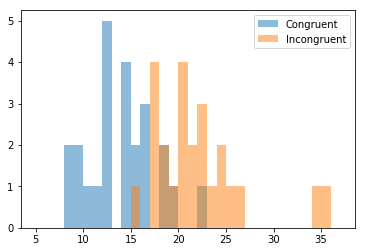

```python
bins = np.linspace(5, 37,33)

plt.hist(stroop.Congruent, bins, alpha=0.5, label='Congruent')
plt.hist(stroop.Incongruent, bins, alpha=0.5, label='Incongruent')
plt.legend(loc='upper right')
plt.show()
```

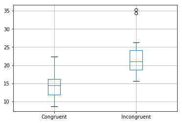

```python
stroop.boxplot()
plt.show()
```

The histogram shows some overlap in the two distributions, and that the incongruent distribution could potentially have a long tail - however that may just be due to low sample size. The boxplots, showing quartiles, paints a more distinct picture of difference, and highlights the two outliers.

(5) Now, perform the statistical test and report the results. What is the confidence level and your critical statistic value? Do you reject the null hypothesis or fail to reject it? Come to a conclusion in terms of the experiment task. Did the results match up with your expectations?

```python
from scipy import stats

test=stats.ttest_ind(stroop.Incongruent,stroop.Congruent,equal_var=False)
```

```python
test.pvalue
```

```
6.5101673904426379e-08
```

As the p value is much less than .05, we can reject the null hypothesis that the two displays have the same response time. This matches expectations, and incongruent displays are perceptually more difficult to process.